# R Notebook

## Setup

First things, first. Let’s load all the necessary libraries we’ll need!

```r
library(tidyverse)
```

[output not shown]

```r
library(summarytools)
library(here) # Find current working directory and directories of files
library(skimr) # View summary statistics
library(janitor) # R functions to find duplicate values
```

## Load survey data

You have 1 of two options to load the survey data. You can use the File drop down, then click on `Import Dataset`, then `From Text (readr)` and follow the UI to import the data.

Alternatively, if you know the file path, you can read the data set using the code below

```r
#store the file path name
file_name <- "survey_file.csv"
#read the survey data, name the dataframe `df`
df <- read_csv(here::here("data", file_name))
```

Let’s preview the survey data

Try this with the Import UI, and/or try doing this by reading the readr documentation and writing your own code

```r
?read_csv
df_raw <- read_csv(here::here("data", file_name),
                   skip = 2)
view(df_raw)
```

[output not shown]

We’ve managed to exclude the metadata from our data frame, but now the column names don’t seem to make sense!

What we’ll need to do instead is store the column names in a separate variable, then read it back in to the data frame.

```r
#store column names
df_names <- read_csv(here::here("data", file_name), n_max=0) %>% names()
# Read the entire file
df_raw <- read_csv(here::here("data", file_name),
               col_names = df_names, # use df_names to title the columns
               skip = 3)             # skip the first three lines
View(df_raw)
```

Let’s use `skim()` to get an overview of our data set

```r
skim(df_raw)
```

[output not shown]

[output not shown]

Now, let’s try using the package `summarytools` to view our data set.

```r
dfSummary(df_raw)
```

```
Data Frame Summary
df_raw
N: 1055
-------------------------------------------------------------------------------------------------------------------------------------------------------
No   Variable                 Stats / Values                    Freqs (% of Valid)       Text Graph                               Valid      Missing
---- ------------------------ --------------------------------- ------------------------ ---------------------------------------- ---------- ----------
1    StartDate                min : 2019-08-13                  27 distinct val.                           :                      1055       0
     [POSIXct, POSIXt]        med : 2019-08-19                                           :                 :                      (100%)     (0%)
                              max : 2019-08-24                                           :                 :
                              range : 11d                                                : : . : . . . : : :
                                                                                         : : : : : : : : : :

2    EndDate                  min : 2019-08-13 00:06:00         937 distinct val.                          :                      1055       0
     [POSIXct, POSIXt]        med : 2019-08-19 01:51:00                                  . .             . :                      (100%)     (0%)
                              max : 2019-08-24 08:17:00                                  : : . .   .   : : :
                              range : 11d 8H 11M 0S                                      : : : : : : : : : :
                                                                                         : : : : : : : : : :

3    Status                   1. IP Address                     1022 (96.9%)             IIIIIIIIIIIIIIII                         1055       0
     [character]              2. Survey Preview                 8 ( 0.8%)                                                         (100%)     (0%)
                              3. Survey Test                    25 ( 2.4%)

4    IPAddress                                                  All NA's                                                          0          1055
     [character]                                                                                                                  (0%)       (100%)

5    Progress                 mean (sd) : 100 (0)               100 : 55 (100.0%)        IIIIIIIIIIIIIIII                         55         1000
     [integer]                min < med < max :                                                                                   (5.21%)    (94.79%)
                              100 < 100 < 100
                              IQR (CV) : 0 (0)

6    Duration (in seconds)    mean (sd) : 0.04 (0.19)           0 : 53 (96.4%)           IIIIIIIIIIIIIIII                         55         1000
     [integer]                min < med < max :                 1 :  2 ( 3.6%)                                                    (5.21%)    (94.79%)
                              0 < 0 < 1
                              IQR (CV) : 0 (5.2)

7    Finished                 1. True                           55 (100.0%)              IIIIIIIIIIIIIIII                         55         1000
     [character]                                                                                                                  (5.21%)    (94.79%)

8    RecordedDate             min : 2019-08-22 16:07:07         13 distinct val.                       :                          55         1000
     [POSIXct, POSIXt]        med : 2019-08-23 11:49:27                                                :                          (5.21%)    (94.79%)
```

[output cut: 165 more lines]

```
                                                                14 :  65 ( 6.2%)         II
                                                                24 :  85 ( 8.1%)         III

40   e                        1. LeahWatsica@gmail.com          12 ( 1.1%)                                                        1055       0
     [character]              2. BransonRunte@hotmail.com       7 ( 0.7%)                                                         (100%)     (0%)
                              3. AshantiMcGlynnDDS@gmail.c      6 ( 0.6%)
                              4. ClaireWillms-Greenholt@ya      5 ( 0.5%)
                              5. Dr.LawsonO'Hara@outlook.c      5 ( 0.5%)
                              6. AaliyahTrantow@yahoo.com       1 ( 0.1%)
                              7. AaronHomenick@hotmail.com      1 ( 0.1%)
                              8. AbbigailSenger-Erdman@gma      1 ( 0.1%)
                              9. AbbyRolfsonDDS@gmail.com       1 ( 0.1%)
                              10. AbdullahBradtke@yahoo.com     1 ( 0.1%)
                              [ 1015 others ]                   1015 (91.3%)             IIIIIIIIIIIIIIII
-------------------------------------------------------------------------------------------------------------------------------------------------------
```

```r
#same code, but more readable in the Viewer pane
view(dfSummary(df_raw))
```

What do you notice? We can see the min and max of the start dates for the survey, we can see that Q4 has some missing values, Q6 has missing values, 41% of the responses came from ci = 1, and there are 12 of the same emails in column `e.`

This report is helpful in seeing if there are any anomalies or large missing values in the data set. Sometimes this report will catch whether we’ve read the data incorrectly and stop us before we analyze a broken data set.

The column `ci` might not be easily understood by other people trying to read your code. Let’s rename the column to something that’s more readable.

```r
df_raw <-
  df_raw %>%
    rename(city_id = ci)
df_raw
```

| StartDate | EndDate | Status | IPAddress | Progress | Duration (in seconds) | Finished | RecordedDate | ResponseId | RecipientLastName | RecipientFirstName | RecipientEmail | ExternalReference | LocationLatitude | LocationLongitude | DistributionChannel | UserLanguage | Q1 | Q2 | Q3_1 | Q3_2 | Q3_3 | Q3_4 | Q3_5 | Q3_6 | Q4 | Q4_10_TEXT | Q5 | Q6 | Q6_4_TEXT | … |
| --- | --- | --- | --- | --- | --- | --- | --- | --- | --- | --- | --- | --- | --- | --- | --- | --- | --- | --- | --- | --- | --- | --- | --- | --- | --- | --- | --- | --- | --- | --- |
| 2019-08-22 16:07:06 | 2019-08-22 21:04:06 | IP Address | NA | 100 | 1 | True | 2019-08-22 16:07:07 | R_9zvoQDsmu20z1Qh | NA | NA | NA | NA | 37.7771 | -122.406 | test | NA | 2-6 times a week | 3 | I'm ordering for a group | NA | NA | NA | I don't have the time to cook | NA | Burgers | NA | Somewhat satisfied | Mobile app on smartphone | NA | … |
| 2019-08-22 16:07:07 | 2019-08-22 23:54:07 | IP Address | NA | 100 | 0 | True | 2019-08-22 16:07:07 | R_e4p8ny0sH082eyN | NA | NA | NA | NA | 37.7771 | -122.406 | test | NA | Once a month or less | 0 | NA | NA | NA | NA | I don't have the time to cook | NA | Other | Atque venenatis sodales, viverra venenatis rhoncus fusce eros consequat nibh interdum. Vivamus. Rhoncus. | Somewhat satisfied | Mobile app on smartphone | NA | … |
| 2019-08-22 16:07:07 | 2019-08-22 23:23:07 | IP Address | NA | 100 | 0 | True | 2019-08-22 16:07:07 | R_bPZv2lmt6jcn4O1 | NA | NA | NA | NA | 37.7771 | -122.406 | test | NA | Once a month or less | 0 | NA | NA | NA | NA | I don't have the time to cook | NA | Burgers | NA | Extremely dissatisfied | Web browser on desktop or laptop | NA | … |
| 2019-08-22 16:07:07 | 2019-08-22 17:28:07 | IP Address | NA | 100 | 0 | True | 2019-08-22 16:07:07 | R_6FpqxxCv1RLNXTf | NA | NA | NA | NA | 37.7771 | -122.406 | test | NA | Once a week | 2 | NA | NA | NA | NA | I don't have the time to cook | NA | Pizza | Bibendum faucibus fusce leo amet facilisi montes fermentum dui! Vitae commodo? Aenean leo. | Somewhat satisfied | NA | Laoreet eu magnis fermentum atque? Felis porta vel curabitur. Convallis turpis. | … |
| 2019-08-22 16:07:08 | 2019-08-22 23:56:08 | IP Address | NA | 100 | 0 | True | 2019-08-22 16:07:08 | R_8oUiruxuVS0xYTr | NA | NA | NA | NA | 37.7771 | -122.406 | test | NA | Once a week | 2 | I'm ordering for a group | NA | NA | NA | NA | NA | Pizza | NA | Neither satisfied nor dissatisfied | Web browser on desktop or laptop | Orci tortor augue mi? Volutpat mi ultrices ipsum atque lacus rutrum a, felis. | … |
| 2019-08-23 11:49:22 | 2019-08-23 20:05:22 | IP Address | NA | 100 | 0 | True | 2019-08-23 11:49:23 | R_3gGaQ3x0EV9LkiN | NA | NA | NA | NA | 37.7771 | -122.406 | test | NA | Once a month or less | 0 | I'm ordering for a group | NA | NA | NA | I don't have the time to cook | NA | Chinese | NA | Extremely dissatisfied | Mobile app on smartphone | NA | … |
| 2019-08-23 11:49:23 | 2019-08-23 16:45:23 | IP Address | NA | 100 | 0 | True | 2019-08-23 11:49:23 | R_0r1ZiWcHSIrJpnn | NA | NA | NA | NA | 37.7771 | -122.406 | test | NA | 2-3 times a month | 1 | I'm ordering for a group | NA | NA | NA | NA | NA | Burgers | NA | Somewhat satisfied | Phone call | NA | … |
| 2019-08-23 11:49:23 | 2019-08-23 14:26:23 | IP Address | NA | 100 | 0 | True | 2019-08-23 11:49:23 | R_eFOpdvZ3c60pfvv | NA | NA | NA | NA | 37.7771 | -122.406 | test | NA | 2-6 times a week | 3 | NA | NA | NA | I don't have any groceries | NA | NA | Burgers | NA | Somewhat satisfied | Other: | NA | … |
| 2019-08-23 11:49:23 | 2019-08-23 12:00:23 | IP Address | NA | 100 | 0 | True | 2019-08-23 11:49:23 | R_bJAFAD5zp9e0Qap | NA | NA | NA | NA | 37.7771 | -122.406 | test | NA | 2-6 times a week | 3 | I'm ordering for a group | NA | NA | NA | I don't have the time to cook | Other: | Pizza | NA | Neither satisfied nor dissatisfied | Mobile app on smartphone | NA | … |
| 2019-08-23 11:49:23 | 2019-08-23 12:01:23 | IP Address | NA | 100 | 0 | True | 2019-08-23 11:49:23 | R_aaawh7F4474uGUJ | NA | NA | NA | NA | 37.7771 | -122.406 | test | NA | 2-6 times a week | 3 | NA | NA | NA | NA | I don't have the time to cook | NA | Indian | NA | Somewhat satisfied | Mobile app on smartphone | NA | … |

[output cut: 990 more lines]

From the summary report, it looks like there are a few duplicate emails. Let’s count how many duplicates there are.

```r
df_raw %>%
  group_by(e) %>%
  count() %>%
  arrange(desc(n))
```

| e | n |
| --- | --- |
| LeahWatsica@gmail.com | 12 |
| BransonRunte@hotmail.com | 7 |
| AshantiMcGlynnDDS@gmail.com | 6 |
| ClaireWillms-Greenholt@yahoo.com | 5 |
| Dr.LawsonO'Hara@outlook.com | 5 |
| AaliyahTrantow@yahoo.com | 1 |
| AaronHomenick@hotmail.com | 1 |
| AbbigailSenger-Erdman@gmail.com | 1 |
| AbbyRolfsonDDS@gmail.com | 1 |
| AbdullahBradtke@yahoo.com | 1 |

[output cut: 990 more lines]

This time, let’s use the `janitor` package to find duplicate emails.

```r
df_raw %>%
  get_dupes(e)
```

| e | dupe_count | StartDate | EndDate | Status | IPAddress | Progress | Duration (in seconds) | Finished | RecordedDate | ResponseId | RecipientLastName | RecipientFirstName | RecipientEmail | ExternalReference | LocationLatitude | LocationLongitude | DistributionChannel | UserLanguage | Q1 | Q2 | Q3_1 | Q3_2 | Q3_3 | Q3_4 | Q3_5 | Q3_6 | Q4 | Q4_10_TEXT | Q5 | … |
| --- | --- | --- | --- | --- | --- | --- | --- | --- | --- | --- | --- | --- | --- | --- | --- | --- | --- | --- | --- | --- | --- | --- | --- | --- | --- | --- | --- | --- | --- | --- |
| AshantiMcGlynnDDS@gmail.com | 6 | 2019-08-22 16:07:06 | 2019-08-22 21:04:06 | IP Address | NA | 100 | 1 | True | 2019-08-22 16:07:07 | R_9zvoQDsmu20z1Qh | NA | NA | NA | NA | 37.7771 | -122.406 | test | NA | 2-6 times a week | 3 | I'm ordering for a group | NA | NA | NA | I don't have the time to cook | NA | Burgers | NA | Somewhat satisfied | … |
| AshantiMcGlynnDDS@gmail.com | 6 | 2019-08-22 16:07:07 | 2019-08-22 23:54:07 | IP Address | NA | 100 | 0 | True | 2019-08-22 16:07:07 | R_e4p8ny0sH082eyN | NA | NA | NA | NA | 37.7771 | -122.406 | test | NA | Once a month or less | 0 | NA | NA | NA | NA | I don't have the time to cook | NA | Other | Atque venenatis sodales, viverra venenatis rhoncus fusce eros consequat nibh interdum. Vivamus. Rhoncus. | Somewhat satisfied | … |
| AshantiMcGlynnDDS@gmail.com | 6 | 2019-08-22 16:07:07 | 2019-08-22 23:23:07 | IP Address | NA | 100 | 0 | True | 2019-08-22 16:07:07 | R_bPZv2lmt6jcn4O1 | NA | NA | NA | NA | 37.7771 | -122.406 | test | NA | Once a month or less | 0 | NA | NA | NA | NA | I don't have the time to cook | NA | Burgers | NA | Extremely dissatisfied | … |
| AshantiMcGlynnDDS@gmail.com | 6 | 2019-08-22 16:07:07 | 2019-08-22 17:28:07 | IP Address | NA | 100 | 0 | True | 2019-08-22 16:07:07 | R_6FpqxxCv1RLNXTf | NA | NA | NA | NA | 37.7771 | -122.406 | test | NA | Once a week | 2 | NA | NA | NA | NA | I don't have the time to cook | NA | Pizza | Bibendum faucibus fusce leo amet facilisi montes fermentum dui! Vitae commodo? Aenean leo. | Somewhat satisfied | … |
| AshantiMcGlynnDDS@gmail.com | 6 | 2019-08-22 16:07:08 | 2019-08-22 23:56:08 | IP Address | NA | 100 | 0 | True | 2019-08-22 16:07:08 | R_8oUiruxuVS0xYTr | NA | NA | NA | NA | 37.7771 | -122.406 | test | NA | Once a week | 2 | I'm ordering for a group | NA | NA | NA | NA | NA | Pizza | NA | Neither satisfied nor dissatisfied | … |
| AshantiMcGlynnDDS@gmail.com | 6 | 2019-08-23 11:49:22 | 2019-08-23 20:05:22 | IP Address | NA | 100 | 0 | True | 2019-08-23 11:49:23 | R_3gGaQ3x0EV9LkiN | NA | NA | NA | NA | 37.7771 | -122.406 | test | NA | Once a month or less | 0 | I'm ordering for a group | NA | NA | NA | I don't have the time to cook | NA | Chinese | NA | Extremely dissatisfied | … |
| BransonRunte@hotmail.com | 7 | 2019-08-23 11:49:27 | 2019-08-23 13:10:27 | IP Address | NA | 100 | 0 | True | 2019-08-23 11:49:27 | R_0CBQZdfvS7lsTXv | NA | NA | NA | NA | 37.7771 | -122.406 | test | NA | Once a week | 2 | I'm ordering for a group | NA | NA | NA | NA | NA | Pizza | NA | Somewhat satisfied | … |
| BransonRunte@hotmail.com | 7 | 2019-08-23 11:49:27 | 2019-08-23 19:33:27 | IP Address | NA | 100 | 1 | True | 2019-08-23 11:49:28 | R_1TFqgjkpF2J1MjP | NA | NA | NA | NA | 37.7771 | -122.406 | test | NA | Daily | 4 or more | NA | NA | NA | NA | I don't have the time to cook | NA | Thai | NA | Somewhat satisfied | … |
| BransonRunte@hotmail.com | 7 | 2019-08-23 11:49:28 | 2019-08-23 18:49:28 | IP Address | NA | 100 | 0 | True | 2019-08-23 11:49:28 | R_8dXVpZoIYUIyf7T | NA | NA | NA | NA | 37.7771 | -122.406 | test | NA | 2-3 times a month | 1 | NA | NA | I want a specific meal or item | I don't have any groceries | I don't have the time to cook | NA | Burgers | NA | Somewhat dissatisfied | … |
| BransonRunte@hotmail.com | 7 | 2019-08-23 11:49:28 | 2019-08-23 18:05:28 | IP Address | NA | 100 | 0 | True | 2019-08-23 11:49:28 | R_4O8JXFKn5ZUFgtT | NA | NA | NA | NA | 37.7771 | -122.406 | test | NA | Daily | 4 or more | I'm ordering for a group | NA | NA | NA | I don't have the time to cook | NA | Other | NA | Somewhat satisfied | … |

[output cut: 25 more lines]

Let’s delete the duplicate emails and keep the first response from the duplicated emails.

```r
#Remove duplicate emails, keep the first submission date
df_raw <- df_raw %>%
  group_by(e) %>%
  slice(which.min(StartDate)) %>%
  ungroup()
```

Let’s double check that we’ve removed all of the duplicates

```r
df_raw %>%
  get_dupes(e)
```

```
No duplicate combinations found of: e
```

| e | dupe_count | StartDate | EndDate | Status | IPAddress | Progress | Duration (in seconds) | Finished | RecordedDate | ResponseId | RecipientLastName | RecipientFirstName | RecipientEmail | ExternalReference | LocationLatitude | LocationLongitude | DistributionChannel | UserLanguage | Q1 | Q2 | Q3_1 | Q3_2 | Q3_3 | Q3_4 | Q3_5 | Q3_6 | Q4 | Q4_10_TEXT | Q5 | … |
| --- | --- | --- | --- | --- | --- | --- | --- | --- | --- | --- | --- | --- | --- | --- | --- | --- | --- | --- | --- | --- | --- | --- | --- | --- | --- | --- | --- | --- | --- | --- |

```r
NA
```

We also have some demographic data of the respondents that lives in the data folder in the file called, “distinct_demos.csv”

Let’s read in the distinct_demo’s csv as “demo_data”

```r
demo_data <- read_csv(here::here("data", "distinct_demos.csv"))
```

Now, let’s create one merged table by joining the `df_raw` table with the `demo_data` table and call it `df`

```r
#Uncomment the code and run it
# df_raw %>%
#   left_join(demo_data)
```

Why did this error out? Turns out R doesn’t know what unique key to join the two tables. We can either rename the `e` column in `df_raw` to `email` or we can tell the `left_join()` function which columns to merge on.

[output not shown]

[output cut: 990 more lines]

Use `dfSummary` to quick view the data set.

Let’s analyze Question 1!

First, let’s store a function that calculates the margin of error where p = sample proportion, n = sample size, and z is the critical value (z-score).

```r
calc_moe <- function(p,n, z=1.96){
  x <- z*sqrt(p*(1-p)/n)
  return(x)
}
```

Now, let’s calculcate a frequency table of the responses from Question 1, with the margin of error for each response.

```r
Q1_table <- df_raw %>%
  group_by(Q1) %>%
  summarize(n = n()) %>%
  mutate(total = sum(n),
         proportion = (n/total),
         moe = calc_moe(proportion, total),
         lower = proportion - moe,
         upper = proportion + moe
  )

Q1_table
```

| Q1 | n | total | proportion | moe | lower | upper |
| --- | --- | --- | --- | --- | --- | --- |
| 2-3 times a month | 203 | 1025 | 0.19804878 | 0.02439800 | 0.17365078 | 0.22244678 |
| 2-6 times a week | 260 | 1025 | 0.25365854 | 0.02663714 | 0.22702139 | 0.28029568 |
| Daily | 63 | 1025 | 0.06146341 | 0.01470375 | 0.04675967 | 0.07616716 |
| Once a month or less | 213 | 1025 | 0.20780488 | 0.02483923 | 0.18296565 | 0.23264411 |
| Once a week | 286 | 1025 | 0.27902439 | 0.02745842 | 0.25156597 | 0.30648281 |

Let’s plot the frequency table using ggplot!

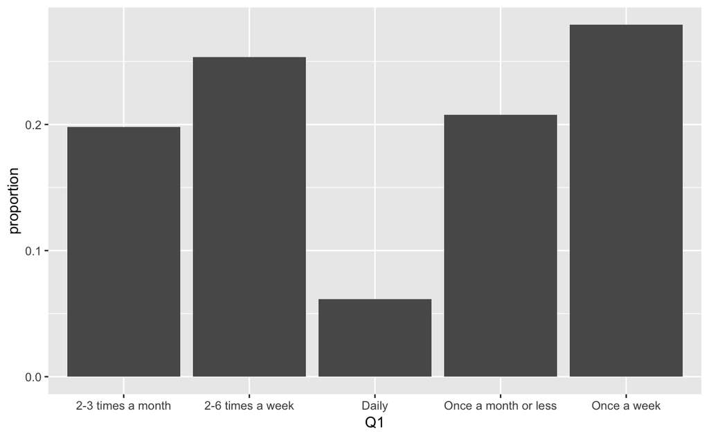

```r
Q1_table %>%
  ggplot(aes(x = Q1, y = proportion)) +
  geom_col()
```

Hmm, looks like we want to reorder the bars from the order in which the response options were shown.

Let’s re-level the response options to give them order.

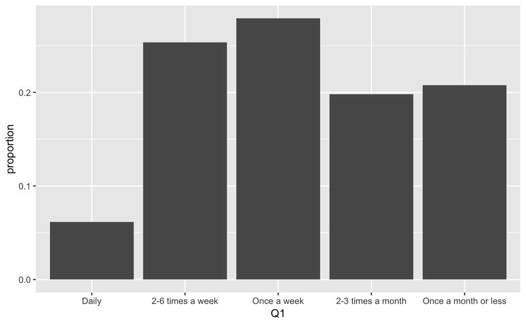

```r
Q1_table <-
  Q1_table %>%
  mutate(Q1 =
          fct_relevel(Q1,
                      "Daily",
                      "2-6 times a week",
                      "Once a week",
                      "2-3 times a month",
                      "Once a month or less")
  )
Q1_table %>%
  ggplot(aes(x = Q1, y = proportion)) +
  geom_col()
```

Now let’s get fancy. Let’s color the bars, add the error bars, add labels to the bars and to the graph.

To understand what each line of code does, try commenting out a line and rerunning the code. Can you spot what’s different?

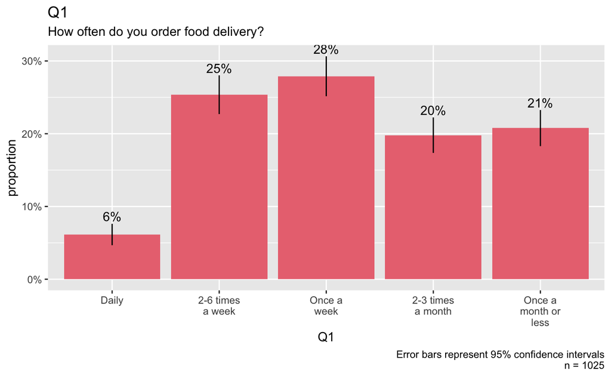

```r
Q1_table %>%
  ggplot(aes(x = Q1, y = proportion)) +
  geom_col(fill = "#EA7580") +
  geom_errorbar(
    aes(ymin = lower, ymax = upper),
    size = .5,
    width = 0,
    position = position_dodge(.7)
  ) +
  geom_text(aes(label = paste0(round(proportion*100), "%"), y = upper), vjust = -.3) +
  labs (
    title = "Q1",
    subtitle = "How often do you order food delivery?",
    caption = glue("Error bars represent 95% confidence intervals\nn = {Q1_table$total}")
  ) +
  scale_y_continuous(labels = scales::percent) +
  scale_x_discrete(labels = function(x) str_wrap(x, width = 10))
```

Now let’s do Q2.

```r
Q2_table <- df_raw %>%
  group_by(Q2) %>%
  summarize(n = n()) %>%
  mutate(total = sum(n),
         proportion = (n/total),
         moe = calc_moe(proportion, total),
         lower = proportion - moe,
         upper = proportion + moe
  )
Q2_table
```

| Q2 | n | total | proportion | moe | lower | upper |
| --- | --- | --- | --- | --- | --- | --- |
| 0 | 213 | 1025 | 0.20780488 | 0.02483923 | 0.18296565 | 0.23264411 |
| 1 | 203 | 1025 | 0.19804878 | 0.02439800 | 0.17365078 | 0.22244678 |
| 2 | 286 | 1025 | 0.27902439 | 0.02745842 | 0.25156597 | 0.30648281 |
| 3 | 260 | 1025 | 0.25365854 | 0.02663714 | 0.22702139 | 0.28029568 |
| 4 or more | 63 | 1025 | 0.06146341 | 0.01470375 | 0.04675967 | 0.07616716 |

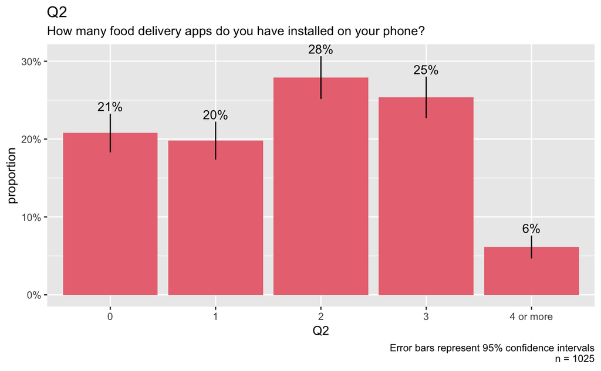

```r
Q2_table %>%
  ggplot(aes(x = Q2, y = proportion)) +
  geom_col(fill = "#EA7580") +
  geom_errorbar(
    aes(ymin = lower, ymax = upper),
    size = .5,
    width = 0,
    position = position_dodge(.7)
  ) +
  geom_text(aes(label = paste0(round(proportion*100), "%"), y = upper), vjust = -.3) +
  labs (
    title = "Q2",
    subtitle = "How many food delivery apps do you have installed on your phone?",
    caption = glue("Error bars represent 95% confidence intervals\nn = {Q2_table$total}")
  ) +
  scale_y_continuous(labels = scales::percent) +
  scale_x_discrete(labels = function(x) str_wrap(x, width = 10))
```

Multi-select questions require different code to analyze from the way it’s stored.

You’ll need to transform the data from wide to long before grouping and calculating the frequencies.

```r
Q3_table <- df_raw %>%
  select(starts_with("Q3")) %>%
  gather(question, response) %>%
  group_by(question) %>%
  count(question, response) %>%
  mutate(total = sum(n),
         proportion = (n/total),
         moe = calc_moe(proportion, total),
         lower = proportion - moe,
         upper = proportion + moe
  ) %>%
  filter(!is.na(response))
Q3_table
```

| question | response | n | total | proportion | moe | lower | upper |
| --- | --- | --- | --- | --- | --- | --- | --- |
| Q3_1 | I'm ordering for a group | 280 | 1025 | 0.27317073 | 0.02727894 | 0.24589180 | 0.30044967 |
| Q3_2 | I don't want to cook | 203 | 1025 | 0.19804878 | 0.02439800 | 0.17365078 | 0.22244678 |
| Q3_3 | I want a specific meal or item | 108 | 1025 | 0.10536585 | 0.01879606 | 0.08656979 | 0.12416191 |
| Q3_4 | I don't have any groceries | 146 | 1025 | 0.14243902 | 0.02139642 | 0.12104260 | 0.16383545 |
| Q3_5 | I don't have the time to cook | 667 | 1025 | 0.65073171 | 0.02918601 | 0.62154570 | 0.67991772 |
| Q3_6 | Other: | 58 | 1025 | 0.05658537 | 0.01414482 | 0.04244054 | 0.07073019 |

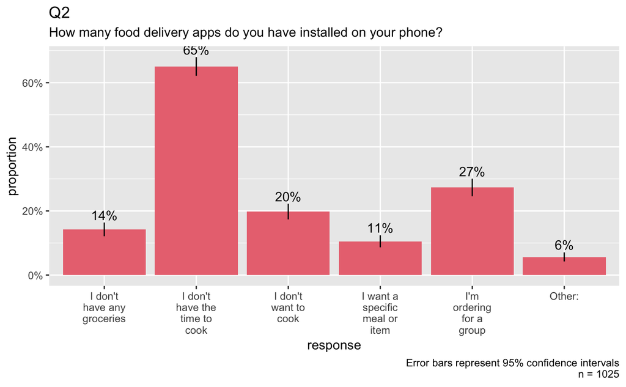

```r
Q3_table %>%
  ggplot(aes(x = response, y = proportion)) +
  geom_col(fill = "#EA7580") +
  geom_errorbar(
    aes(ymin = lower, ymax = upper),
    size = .5,
    width = 0,
    position = position_dodge(.7)
  ) +
  geom_text(aes(label = paste0(round(proportion*100), "%"), y = upper), vjust = -.3) +
  labs (
    title = "Q2",
    subtitle = "How many food delivery apps do you have installed on your phone?",
    caption = glue("Error bars represent 95% confidence intervals\nn = {Q2_table$total}")
  ) +
  scale_y_continuous(labels = scales::percent) +
  scale_x_discrete(labels = function(x) str_wrap(x, width = 10))
```

Let’s reorder the bars by frequency

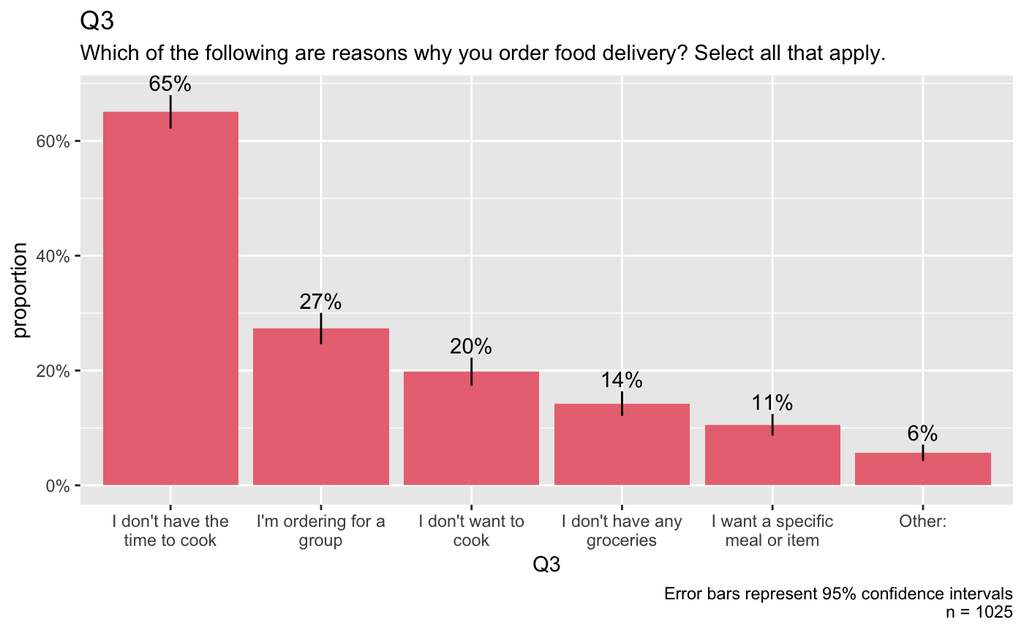

Let’s analyze Q4.

```r
Q4_table <- df_raw %>%
  group_by(Q4) %>%
  summarize(n = n()) %>%
  mutate(total = sum(n),
         proportion = (n/total),
         moe = calc_moe(proportion, total),
         lower = proportion - moe,
         upper = proportion + moe
  )
Q4_table
```

| Q4 | n | total | proportion | moe | lower | upper |
| --- | --- | --- | --- | --- | --- | --- |
| American | 70 | 1025 | 0.06829268 | 0.015442620 | 0.05285006 | 0.08373530 |
| Burgers | 259 | 1025 | 0.25268293 | 0.026603240 | 0.22607969 | 0.27928617 |
| Chinese | 31 | 1025 | 0.03024390 | 0.010484418 | 0.01975948 | 0.04072832 |
| Indian | 56 | 1025 | 0.05463415 | 0.013913173 | 0.04072097 | 0.06854732 |
| Italian | 62 | 1025 | 0.06048780 | 0.014594165 | 0.04589364 | 0.07508197 |
| Mexican | 95 | 1025 | 0.09268293 | 0.017753073 | 0.07492985 | 0.11043600 |
| Other | 26 | 1025 | 0.02536585 | 0.009625863 | 0.01573999 | 0.03499172 |
| Pizza | 297 | 1025 | 0.28975610 | 0.027772450 | 0.26198365 | 0.31752855 |
| Sushi | 26 | 1025 | 0.02536585 | 0.009625863 | 0.01573999 | 0.03499172 |
| Thai | 90 | 1025 | 0.08780488 | 0.017325961 | 0.07047892 | 0.10513084 |

[output cut: 1 more lines]

We notice that a few counts are `NA` which means a few respondents skipped this question. Let’s be sure to remove these null values from our total n size.

```r
Q4_table <-
  df_raw %>%
  filter(!is.na(Q4)) %>%
  group_by(Q4) %>%
  summarize(n = n()) %>%
  mutate(total = sum(n),
         proportion = (n/total),
         moe = calc_moe(proportion, total),
         lower = proportion - moe,
         upper = proportion + moe
  )
Q4_table
```

| Q4 | n | total | proportion | moe | lower | upper |
| --- | --- | --- | --- | --- | --- | --- |
| American | 70 | 1012 | 0.06916996 | 0.015633628 | 0.05353633 | 0.08480359 |
| Burgers | 259 | 1012 | 0.25592885 | 0.026886401 | 0.22904245 | 0.28281525 |
| Chinese | 31 | 1012 | 0.03063241 | 0.010616972 | 0.02001544 | 0.04124938 |
| Indian | 56 | 1012 | 0.05533597 | 0.014086667 | 0.04124930 | 0.06942264 |
| Italian | 62 | 1012 | 0.06126482 | 0.014775526 | 0.04648930 | 0.07604035 |
| Mexican | 95 | 1012 | 0.09387352 | 0.017969325 | 0.07590419 | 0.11184284 |
| Other | 26 | 1012 | 0.02569170 | 0.009747886 | 0.01594381 | 0.03543959 |
| Pizza | 297 | 1012 | 0.29347826 | 0.028055405 | 0.26542286 | 0.32153367 |
| Sushi | 26 | 1012 | 0.02569170 | 0.009747886 | 0.01594381 | 0.03543959 |
| Thai | 90 | 1012 | 0.08893281 | 0.017537675 | 0.07139513 | 0.10647048 |

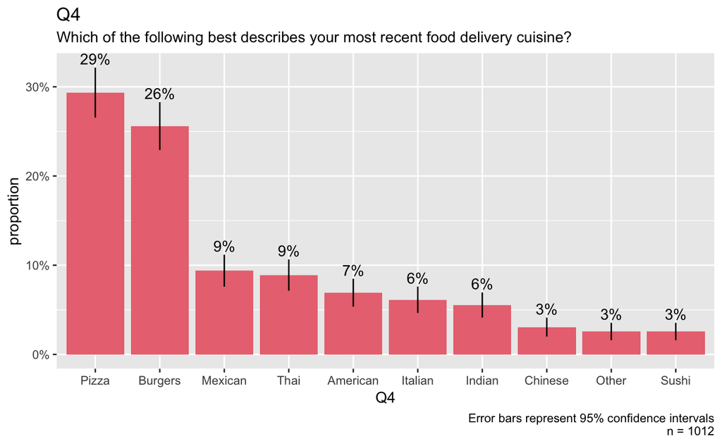

```r
Q4_table %>%
  ggplot(aes(x = reorder(Q4, -proportion), y = proportion)) +
  geom_col(fill = "#EA7580") +
  geom_errorbar(
    aes(ymin = lower, ymax = upper),
    size = .5,
    width = 0,
    position = position_dodge(.7)
  ) +
  geom_text(aes(label = paste0(round(proportion*100), "%"), y = upper), vjust = -.3) +
  labs (
    x = "Q4",
    title = "Q4",
    subtitle = "Which of the following best describes your most recent food delivery cuisine?",
    caption = glue("Error bars represent 95% confidence intervals\nn = {Q4_table$total}")
  ) +
  scale_y_continuous(labels = scales::percent) +
  scale_x_discrete(labels = function(x) str_wrap(x, width = 10))
```

Let’s look at Q5’s satisfaction question. We’ll want to relevel the response options so they are plotted in order.

```r
Q5_table <- df_raw %>%
  group_by(Q5) %>%
  summarize(n = n()) %>%
  mutate(total = sum(n),
         proportion = (n/total),
         moe = calc_moe(proportion, total),
         lower = proportion - moe,
         upper = proportion + moe
  ) %>%
  mutate(Q5 =
          fct_relevel(Q5,
                      "Extremely dissatisfied",
                      "Somewhat dissatisfied",
                      "Neither satisfied nor dissatisfied",
                      "Somewhat satisfied",
                      "Extremely satisfied")
  )
Q5_table
```

| Q5 | n | total | proportion | moe | lower | upper |
| --- | --- | --- | --- | --- | --- | --- |
| Extremely dissatisfied | 105 | 1025 | 0.10243902 | 0.01856346 | 0.08387557 | 0.1210025 |
| Extremely satisfied | 93 | 1025 | 0.09073171 | 0.01758408 | 0.07314763 | 0.1083158 |
| Neither satisfied nor dissatisfied | 254 | 1025 | 0.24780488 | 0.02643104 | 0.22137383 | 0.2742359 |
| Somewhat dissatisfied | 224 | 1025 | 0.21853659 | 0.02529942 | 0.19323717 | 0.2438360 |
| Somewhat satisfied | 349 | 1025 | 0.34048780 | 0.02901057 | 0.31147723 | 0.3694984 |

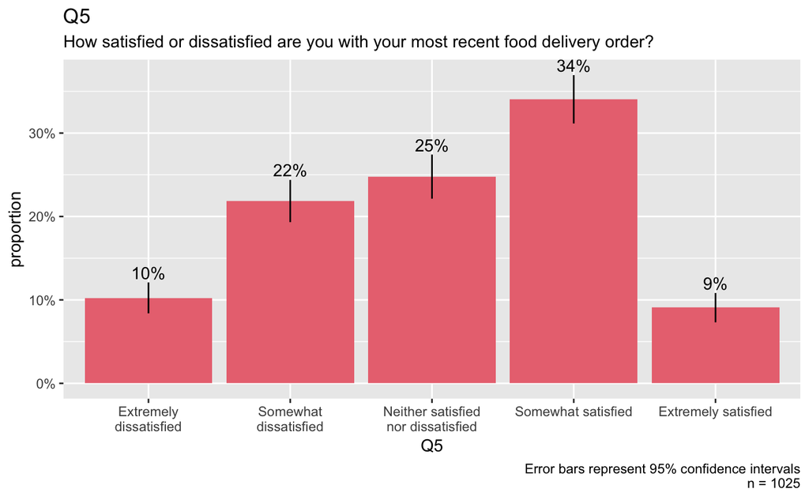

```r
Q5_table %>%
  ggplot(aes(x = Q5, y = proportion)) +
  geom_col(fill = "#EA7580") +
  geom_errorbar(
    aes(ymin = lower, ymax = upper),
    size = .5,
    width = 0,
    position = position_dodge(.7)
  ) +
  geom_text(aes(label = paste0(round(proportion*100), "%"), y = upper), vjust = -.3) +
  labs (
    title = "Q5",
    subtitle = "How satisfied or dissatisfied are you with your most recent food delivery order?",
    caption = glue("Error bars represent 95% confidence intervals\nn = {Q5_table$total}")
  ) +
  scale_y_continuous(labels = scales::percent) +
  scale_x_discrete(labels = function(x) str_wrap(x, width = 20))
```

Sometimes our stakeholders are only interested in the Top 2 Boxes. Let’s calculate them by grouping the variables together. We can do this by using the `case_when()` function.

```r
Q5_table_top2 <-
  df_raw %>%
  mutate(Q5 = case_when(
      Q5 %in% c("Extremely dissatisfied","Somewhat dissatisfied") ~ "Dissatisfied",
      Q5 %in% c("Extremely satisfied", "Somewhat satisfied") ~ "Satisfied",
      Q5 == "Neither satisfied nor dissatisfied" ~ "Neither"
    )) %>%
  group_by(Q5) %>%
  summarize(n = n()) %>%
  mutate(total = sum(n),
         proportion = (n/total),
         moe = calc_moe(proportion, total),
         lower = proportion - moe,
         upper = proportion + moe
)

Q5_table_top2
```

| Q5 | n | total | proportion | moe | lower | upper |
| --- | --- | --- | --- | --- | --- | --- |
| Dissatisfied | 329 | 1025 | 0.3209756 | 0.02858070 | 0.2923949 | 0.3495563 |
| Neither | 254 | 1025 | 0.2478049 | 0.02643104 | 0.2213738 | 0.2742359 |
| Satisfied | 442 | 1025 | 0.4312195 | 0.03031906 | 0.4009005 | 0.4615386 |

```r
NA
```

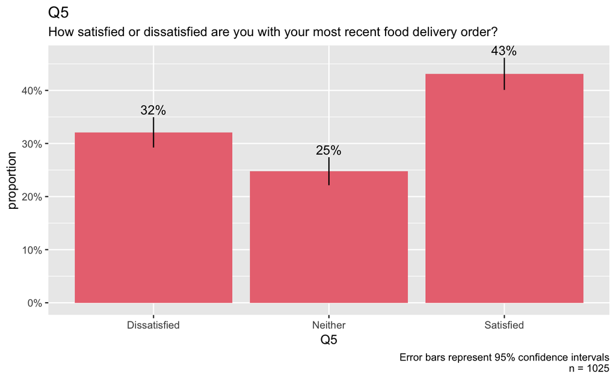

```r
Q5_table_top2 %>%
  ggplot(aes(x = Q5, y = proportion)) +
  geom_col(fill = "#EA7580") +
  geom_errorbar(
    aes(ymin = lower, ymax = upper),
    size = .5,
    width = 0,
    position = position_dodge(.7)
  ) +
  geom_text(aes(label = paste0(round(proportion*100), "%"), y = upper), vjust = -.3) +
  labs (
    title = "Q5",
    subtitle = "How satisfied or dissatisfied are you with your most recent food delivery order?",
    caption = glue("Error bars represent 95% confidence intervals\nn = {Q5_table$total}")
  ) +
  scale_y_continuous(labels = scales::percent) +
  scale_x_discrete(labels = function(x) str_wrap(x, width = 20))
```

If you remember that we used the `janitor` package earlier, you’ll see they have a function to quickly analyze top2 boxes. Try the function `top_levels()`

```r
top_levels(Q5_table$Q5)
```

```
                         Q5_table$Q5 n percent
      Extremely dissatisfied, Som... 2     0.4
 <<< Middle Group (1 categories) >>> 1     0.2
      Somewhat satisfied, Extreme... 2     0.4
```

```r
top_levels(Q5_table$Q5, n = 1)
```

```
                         Q5_table$Q5 n percent
              Extremely dissatisfied 1     0.2
 <<< Middle Group (3 categories) >>> 3     0.6
                 Extremely satisfied 1     0.2
```

Let’s look at Q6

```r
Q6_table <- df_raw %>%
  group_by(Q6) %>%
  summarize(n = n()) %>%
  mutate(total = sum(n),
         proportion = (n/total),
         moe = calc_moe(proportion, total),
         lower = proportion - moe,
         upper = proportion + moe
  )
Q6_table
```

| Q6 | n | total | proportion | moe | lower | upper |
| --- | --- | --- | --- | --- | --- | --- |
| Mobile app on smartphone | 677 | 1025 | 0.66048780 | 0.02899040 | 0.63149740 | 0.68947821 |
| Other: | 39 | 1025 | 0.03804878 | 0.01171227 | 0.02633651 | 0.04976105 |
| Phone call | 54 | 1025 | 0.05268293 | 0.01367656 | 0.03900637 | 0.06635948 |
| Web browser on desktop or laptop | 210 | 1025 | 0.20487805 | 0.02470920 | 0.18016885 | 0.22958725 |
| NA | 45 | 1025 | 0.04390244 | 0.01254266 | 0.03135978 | 0.05644510 |

Looks like we have respondents who skipped this question. We want the proportion of those who *answered* the question. So let’s remove those who skipped the question from our total n size.

```r
Q6_table <- df_raw %>%
  filter(!is.na(Q6)) %>% #remove null rows from this question
  group_by(Q6) %>%
  summarize(n = n()) %>%
  mutate(total = sum(n),
         proportion = (n/total),
         moe = calc_moe(proportion, total),
         lower = proportion - moe,
         upper = proportion + moe
  )
Q6_table
```

| Q6 | n | total | proportion | moe | lower | upper |
| --- | --- | --- | --- | --- | --- | --- |
| Mobile app on smartphone | 677 | 980 | 0.69081633 | 0.02893561 | 0.66188072 | 0.71975193 |
| Other: | 39 | 980 | 0.03979592 | 0.01223895 | 0.02755697 | 0.05203487 |
| Phone call | 54 | 980 | 0.05510204 | 0.01428629 | 0.04081576 | 0.06938833 |
| Web browser on desktop or laptop | 210 | 980 | 0.21428571 | 0.02569047 | 0.18859525 | 0.23997618 |

Notice how the total is now smaller because we removed the null values.

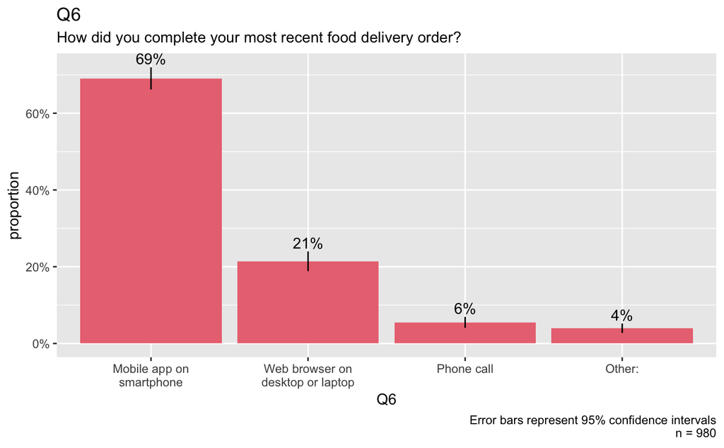

```r
Q6_table %>%
  ggplot(aes(x = reorder(Q6, -proportion), y = proportion)) +
  geom_col(fill = "#EA7580") +
  geom_errorbar(
    aes(ymin = lower, ymax = upper),
    size = .5,
    width = 0,
    position = position_dodge(.7)
  ) +
  geom_text(aes(label = paste0(round(proportion*100), "%"), y = upper), vjust = -.3) +
  labs (
    x = "Q6",
    title = "Q6",
    subtitle = "How did you complete your most recent food delivery order?",
    caption = glue("Error bars represent 95% confidence intervals\nn = {Q6_table$total}")
  ) +
  scale_y_continuous(labels = scales::percent) +
  scale_x_discrete(labels = function(x) str_wrap(x, width = 20))
```

```r
Q7_table <-
  df_raw %>%
  select(starts_with("Q7"), -ends_with("TEXT")) %>%
  gather(question,
         response) %>%
  group_by(question) %>%
  count(question,
        response) %>%
  mutate(
    total = sum(n),
    proportion = n/sum(n),
    moe = calc_moe(proportion, total),
         lower = proportion - moe,
         upper = proportion + moe) %>%
  filter(!is.na(response))
Q7_table
```

| question | response | n | total | proportion | moe | lower | upper |
| --- | --- | --- | --- | --- | --- | --- | --- |
| Q7_1 | Delivery time | 405 | 1025 | 0.39512195 | 0.02992910 | 0.36519285 | 0.42505105 |
| Q7_2 | Food temperature | 188 | 1025 | 0.18341463 | 0.02369256 | 0.15972208 | 0.20710719 |
| Q7_3 | Delivery price | 531 | 1025 | 0.51804878 | 0.03059011 | 0.48745867 | 0.54863889 |
| Q7_4 | Food packaging | 83 | 1025 | 0.08097561 | 0.01670070 | 0.06427491 | 0.09767631 |
| Q7_5 | Courier service | 158 | 1025 | 0.15414634 | 0.02210591 | 0.13204043 | 0.17625225 |
| Q7_6 | Other: | 121 | 1025 | 0.11804878 | 0.01975364 | 0.09829514 | 0.13780242 |

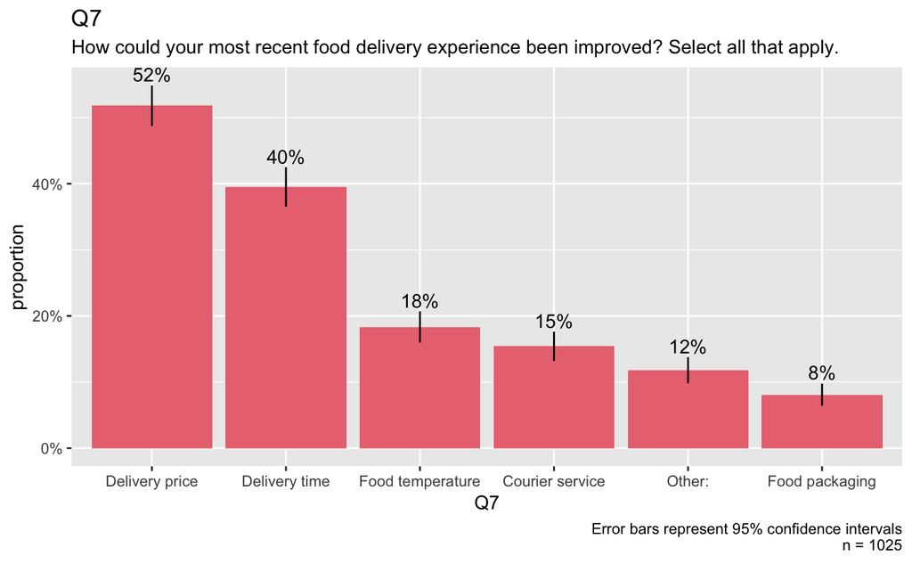

```r
Q7_table %>%
  ggplot(aes(x = reorder(response, -proportion), y = proportion)) +
  geom_col(fill = "#EA7580") +
  geom_errorbar(
    aes(ymin = lower, ymax = upper),
    size = .5,
    width = 0,
    position = position_dodge(.7)
  ) +
  geom_text(aes(label = paste0(round(proportion*100), "%"), y = upper), vjust = -.3) +
  labs (
    x = "Q7",
    title = "Q7",
    subtitle = "How could your most recent food delivery experience been improved? Select all that apply.",
    caption = glue("Error bars represent 95% confidence intervals\nn = {Q7_table$total}")
  ) +
  scale_y_continuous(labels = scales::percent) +
  scale_x_discrete(labels = function(x) str_wrap(x, width = 20))
```

Let’s save this chart as a png so we can include it in a presentation.

```r
ggsave("Q7_plot.png")
```